# Bright spot attribute analysis

Emily Burchfield

## Bright spots attributes

Packages and files needed to run analysis loaded below. All notes on dataset construction can be found in the `BS_data_construction.html` file.

```r
source("BS_func.R")
source("BS_load.R")
```

Null model dataset based on 8650 observations across 5 years.

### Initial variable selection

```r
# find BS
modr <- readRDS("./out/null_LRR.RDS")
lrr <- find_bs(modr, null, level = "LRR", th=1.5)

# merge to indicators dataset
nulli <- merge(nulli %>% select(-c(LRR)), lrr, by = "GEOID", all=T)
nulli <- nulli %>%
  filter(!is.na(BS_CAT))
```

Look and where most of the missing data is:

| Missing data | Variable |
| --- | --- |
| 0.0625434 | perc_wle |
| 0.0302890 | cons_wetlands |
| 0.0301734 | cons_wet_acres |
| 0.0225434 | perc_o |
| 0.0129480 | perc_pe |
| 0.0127168 | cty_pe |
| 0.0123699 | tenant |
| 0.0121387 | crop_sales |
| 0.0092486 | full_owner |
| 0.0058960 | female |
| 0.0058960 | male |
| 0.0054335 | ph_corn |
| 0.0049711 | insect_acres |
| 0.0041618 | part_owner |
| 0.0028902 | chem |
| 0.0026590 | perc_cl |
| 0.0020809 | labor_expense |
| 0.0019653 | cty_cl |
| 0.0019653 | perc_p |
| 0.0013873 | gvt_prog |
| 0.0011561 | fert |
| 0.0009249 | comm_sales |
| 0.0009249 | perc_t |
| 0.0008092 | fert_acres |
| 0.0008092 | herb_acres |
| 0.0008092 | machinery |
| 0.0008092 | cty_al |
| 0.0006936 | income_farm |
| 0.0001156 | age |
| 0.0000000 | GEOID |
| 0.0000000 | YEAR |
| 0.0000000 | STATE_FIPS |
| 0.0000000 | YIELD |
| 0.0000000 | GDD |
| 0.0000000 | SDD |
| 0.0000000 | TP |
| 0.0000000 | EFP |
| 0.0000000 | EXP |
| 0.0000000 | ECO |
| 0.0000000 | CORN_SUIT |
| 0.0000000 | SIDI_NOMASK |

And drop highly correlated variables. Using variables that have no real relationship with the response can cause deterioration in the test error rate; more reason to think through a variable selection procedure prior to running the logistic regression. As in the Cinner et al paper, we keep covariates with correlation coefficients of 0.7:

```r
library(corrplot)
varData <- nulli %>%
  select(-c(STATE_FIPS, YIELD, GDD, SDD, TP, EFP, EXP, ECO, CORN_SUIT, county, LRR, ID,
            STATE, COUNTY_MEAN, REGION_MEAN, DIFF, BS_CAT, GEOID, YEAR)) # remove data from null models
vd <- varData %>% na.omit()
res <- cor(vd)
res <- as.data.frame(as.table(round(res,2)))
res <- res %>% arrange(desc(Freq)) %>% filter(Freq != 1) %>% mutate(aFreq = abs(Freq))
corr <- res %>% filter(aFreq >= 0.7)
```

Update by dropping highly correlated landscape indices:

- Keep only one indicator of diversity (`SDI_AGMASK` and `SDI_NOMASK`) and drop other indicators (`RICH*`, `BPD*`, `SIDI*`)
- `IJI_AGMASK` is highly collinear with `SDI_AGMASK` (`0.85`), less common, and more complex to interpret, so it was dropped.
- `MODE_AG` and `MODE_ALL` are not particularly useful, but interesting. They were dropped.
- Drop `MODE_AG` and `MODE_ALL` b/c not particularly useful in models.
- Remaining collinearity is between `RPR*` and `SE*`. `RPR` is much more common and easier to interpret, so it was kept in the models rather than the Simpson’s Equality indicators.
- Drop `PNC` b/c very collinear with cropland indicator

This resolves the correlation issues:

```r
varData <- nulli %>%
  select(-c(STATE_FIPS, YIELD, GDD, SDD, TP, EFP, EXP, ECO, CORN_SUIT, county, LRR, ID,
            STATE, COUNTY_MEAN, REGION_MEAN, DIFF, BS_CAT, GEOID, YEAR)) %>%
  select(-c(RICH_AGMASK, RICH_NOMASK, SIDI_AGMASK, SIDI_NOMASK, BPD_AGMASK, BPD_NOMASK, IJI_AGMASK,
            MODE_AGMASK, MODE_NOMASK, SE_NOMASK, SE_AGMASK, PERC_NATURAL_COVER))

res <- cor(varData)
res <- as.data.frame(as.table(round(res,2)))
res <- res %>% arrange(desc(Freq)) %>% filter(Freq != 1) %>% mutate(aFreq = abs(Freq))
corr <- res %>% filter(aFreq >= 0.7)
corr
```

```
## [1] Var1  Var2  Freq  aFreq
## <0 rows> (or 0-length row.names)
```

Check for missing data in remaining variables:

```r
# contains missing data overview
qc <- as.data.frame(colSums(is.na(varData)/nrow(varData)))
qc <- cbind(qc, rownames(qc)) %>% arrange(desc(qc$`colSums(is.na(varData)/nrow(varData))`))
```

Drop predictors with more than 10 percent of their data missing:

- `manure_acres` (24%) - will need to focus on other input indicators (fertilizer and chemicals)
- `insur_acres` (22%) - does our `gvt_prog` include this?
- `labor_n` (22%) - proxy with `labor_expense`
- `acres_per_op` (22%) - this is really unfortunate not to include
- `income` (22%) - yield is a proxy of income (correlation of `0.41`) and our BS are based on this
- `insur_op` (22%) - hope that `gvt_prog` includes this
- `exp` (22%) - proxy with `age`
- `occup` (17%) - unfortunate we can’t use, no real suitable proxy other than `age` which will serve as a rough indicator of experience
- `PERC_IRR` (11%) - use `irrig` instead

```r
varData <- nulli %>%
  select(-c(STATE_FIPS, YIELD, GDD, SDD, TP, EFP, EXP, ECO, CORN_SUIT, county, LRR, ID,
            STATE, COUNTY_MEAN, REGION_MEAN, DIFF, BS_CAT, GEOID, YEAR)) %>%
  select(-c(RICH_AGMASK, RICH_NOMASK, SIDI_AGMASK, SIDI_NOMASK, BPD_AGMASK, BPD_NOMASK, IJI_AGMASK,
            MODE_AGMASK, MODE_NOMASK, SE_NOMASK, SE_AGMASK)) %>%
  select(-c(manure_acres, insur_acres, labor_n, acres_per_op, income, insur_op, exp, occup, PERC_IRR))
```

The last step is to clean up the land use data from the Census, much of which is linearly dependent (e.g. one variable is a linear combination of others). The following seem to be the most relevant to our analyses:

```r
varData <- nulli %>%
  select(-c(STATE_FIPS, YIELD, GDD, SDD, TP, EFP, EXP, ECO, CORN_SUIT, county, LRR, ID,
            STATE, COUNTY_MEAN, REGION_MEAN, DIFF, BS_CAT, GEOID, YEAR)) %>%
  select(-c(SIDI_AGMASK, BPD_AGMASK, BPD_NOMASK, IJI_AGMASK,
            MODE_AGMASK, MODE_NOMASK, SE_NOMASK, SE_AGMASK, PERC_NATURAL_COVER, SDI_NOMASK, SDI_AGMASK,
            RPR_NOMASK, RPR_AGMASK, SIDI_NOMASK, RICH_AGMASK)) %>%
  select(-c(manure_acres, insur_acres, labor_n, acres_per_op, insur_op, exp, occup, PERC_IRR)) %>%
  select(-c(perc_cl, perc_clp, perc_o, perc_p, perc_wle, perc_pe, perc_t, cty_al, cty_clp,
            cons_wetlands, cons_wet_acres)) %>%
  select(-c(herb_acres, comm_sales, crop_sales, insect_acres, income_farm, part_owner, fert_acres, income, chem)) %>%
  select(-c( male)) %>%
  mutate(BS_BIN = as.factor(ifelse(nulli$BS_CAT == "Bright Spot", 1, 0)),
         DS_BIN = as.factor(ifelse(nulli$BS_CAT == "Dark Spot", 1, 0)))
```

So the final list of potential predictors in the models run below are:

```
##  [1] "age"           "female"        "fert"          "full_owner"
##  [5] "gvt_prog"      "irrig"         "labor_expense" "machinery"
##  [9] "tenant"        "cty_cl"        "ph_corn"       "ED_NOMASK"
## [13] "IJI_NOMASK"    "LPI_NOMASK"    "RICH_NOMASK"   "cty_pe"
## [17] "BS_BIN"        "DS_BIN"
```

### Final variable list

Farmer demographics

- `age`
- `female`,
- `full_owner`
- `tenant`

Inputs

- `fert` (versus `chem`)
- `irrig`
- `labor_expense`
- `machinery`
- `gvt_prog`

Land use

```r
# check for no wildly collinear variables
vd <- varData %>% na.omit()
res <- cor(vd %>% select(-c(BS_BIN, DS_BIN)))
res <- as.data.frame(as.table(round(res,2)))
res <- res %>% arrange(desc(Freq)) %>% filter(Freq != 1) %>% mutate(aFreq = abs(Freq))
corr <- res %>% filter(aFreq >= 0.7)
corr
```

```
## [1] Var1  Var2  Freq  aFreq
## <0 rows> (or 0-length row.names)
```

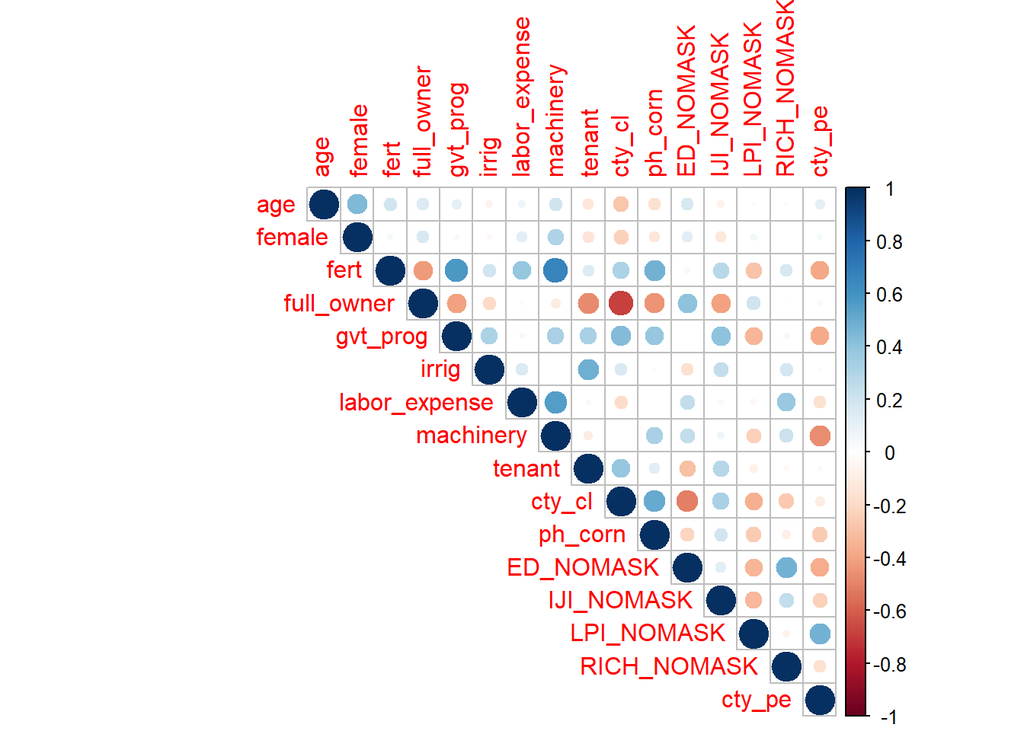

```r
library(corrplot)
res <- cor(varData[,1:(ncol(varData)-2)] %>% na.omit())
corrplot(res, method = "circle", type = "upper")
```

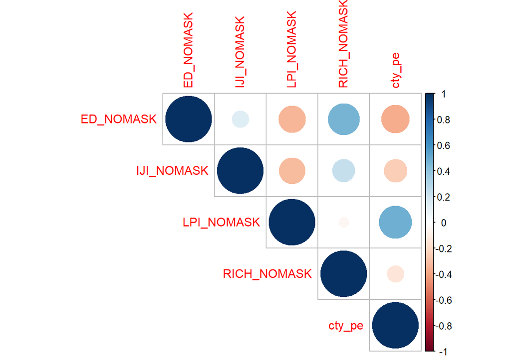

```r
library(corrplot)
res <- cor(varData[,14:ncol(varData)-2] %>% na.omit())
corrplot(res, method = "circle", type = "upper")
```

VIF from linear model with BS:

```r
library(car)
bsm <- glm(BS_BIN ~ ., data = varData %>% select(-c(DS_BIN)), family= binomial(link="logit"))

vif(bsm)
```

```
##           age        female          fert    full_owner      gvt_prog
##      1.767681      1.475113      3.636549      2.991087      2.303913
##         irrig labor_expense     machinery        tenant        cty_cl
##      2.012623      1.800711      3.767169      2.185371      3.863930
##       ph_corn     ED_NOMASK    IJI_NOMASK    LPI_NOMASK   RICH_NOMASK
##      1.677826      3.845568      1.547786      2.419528      1.614579
##        cty_pe
##      2.385151
```

VIF from linear model with DS:

```r
dsm <- glm(BS_BIN ~ ., data = varData %>% select(-c(DS_BIN)), family= binomial(link="logit"))

vif(dsm)
```

```
##           age        female          fert    full_owner      gvt_prog
##      1.767681      1.475113      3.636549      2.991087      2.303913
##         irrig labor_expense     machinery        tenant        cty_cl
##      2.012623      1.800711      3.767169      2.185371      3.863930
##       ph_corn     ED_NOMASK    IJI_NOMASK    LPI_NOMASK   RICH_NOMASK
##      1.677826      3.845568      1.547786      2.419528      1.614579
##        cty_pe
##      2.385151
```

Descriptive statistics for each variable:

```r
summary(varData)
```

```
##       age            female             fert            full_owner
##  Min.   :44.70   Min.   : 0.0774   Min.   :  0.2915   Min.   : 3.001
##  1st Qu.:54.40   1st Qu.: 3.2715   1st Qu.: 12.6095   1st Qu.:21.778
##  Median :56.30   Median : 5.8582   Median : 23.9461   Median :32.936
##  Mean   :56.22   Mean   : 8.5841   Mean   : 31.8522   Mean   :34.837
##  3rd Qu.:58.10   3rd Qu.:10.0208   3rd Qu.: 44.2859   3rd Qu.:46.611
##  Max.   :65.30   Max.   :65.7598   Max.   :483.4235   Max.   :87.059
##  NA's   :1       NA's   :51        NA's   :10         NA's   :80
##     gvt_prog           irrig         labor_expense         machinery
##  Min.   : 0.1148   Min.   : 0.0005   Min.   :   0.1398   Min.   :  10.35
##  1st Qu.: 5.9268   1st Qu.: 0.2164   1st Qu.:   9.8735   1st Qu.: 200.28
##  Median :11.0790   Median : 0.9577   Median :  19.3141   Median : 313.09
##  Mean   :12.3983   Mean   : 6.0235   Mean   :  37.8030   Mean   : 354.39
##  3rd Qu.:16.9237   3rd Qu.: 4.5208   3rd Qu.:  38.2873   3rd Qu.: 476.76
##  Max.   :82.9502   Max.   :80.9212   Max.   :2542.6824   Max.   :3949.10
##  NA's   :12        NA's   :747       NA's   :18          NA's   :7
##      tenant             cty_cl           ph_corn          ED_NOMASK
##  Min.   : 0.04473   Min.   :  1.055   Min.   : 0.1216   Min.   : 11.07
##  1st Qu.: 3.88329   1st Qu.: 18.871   1st Qu.:12.5559   1st Qu.:110.38
##  Median : 6.95643   Median : 37.701   Median :27.4086   Median :139.27
##  Mean   : 8.60775   Mean   : 41.375   Mean   :28.7542   Mean   :148.99
##  3rd Qu.:11.20483   3rd Qu.: 62.410   3rd Qu.:43.7284   3rd Qu.:188.96
##  Max.   :69.24904   Max.   :127.901   Max.   :99.8621   Max.   :298.44
##  NA's   :107        NA's   :17        NA's   :47
##    IJI_NOMASK      LPI_NOMASK       RICH_NOMASK        cty_pe
##  Min.   :16.73   Min.   : 0.2988   Min.   :19.20   Min.   :  0.03229
##  1st Qu.:45.84   1st Qu.: 2.2543   1st Qu.:29.20   1st Qu.:  1.69286
##  Median :49.33   Median : 4.7712   Median :32.70   Median :  4.33118
##  Mean   :48.75   Mean   : 9.8793   Mean   :34.26   Mean   : 11.49972
##  3rd Qu.:52.38   3rd Qu.:11.0354   3rd Qu.:37.90   3rd Qu.: 14.11244
##  Max.   :64.38   Max.   :96.0429   Max.   :74.70   Max.   :100.87980
##                                                    NA's   :110
##  BS_BIN   DS_BIN
##  0:8152   0:8160
##  1: 498   1: 490
##
##
##
##
##
```

```r
library(stargazer)
stargazer(varData, type = "text", title="Descriptive statistics", digits=1)
```

```
##
## Descriptive statistics
## ==================================================================
## Statistic       N   Mean  St. Dev.  Min  Pctl(25) Pctl(75)   Max
## ------------------------------------------------------------------
## age           8,649 56.2    2.7    44.7    54.4     58.1    65.3
## female        8,599  8.6    8.0     0.1    3.3      10.0    65.8
## fert          8,640 31.9    26.3    0.3    12.6     44.3    483.4
## full_owner    8,570 34.8    15.7    3.0    21.8     46.6    87.1
## gvt_prog      8,638 12.4    8.6     0.1    5.9      16.9    83.0
## irrig         7,903  6.0    12.6   0.001   0.2      4.5     80.9
## labor_expense 8,632 37.8    73.0    0.1    9.9      38.3   2,542.7
## machinery     8,643 354.4  213.8   10.3   200.3    476.8   3,949.1
## tenant        8,543  8.6    6.9    0.04    3.9      11.2    69.2
## cty_cl        8,633 41.4    25.3    1.1    18.9     62.4    127.9
## ph_corn       8,603 28.8    18.0    0.1    12.6     43.7    99.9
## ED_NOMASK     8,650 149.0   52.6   11.1   110.4    189.0    298.4
## IJI_NOMASK    8,650 48.8    5.4    16.7    45.8     52.4    64.4
## LPI_NOMASK    8,650  9.9    13.6    0.3    2.3      11.0    96.0
## RICH_NOMASK   8,650 34.3    7.4    19.2    29.2     37.9    74.7
## cty_pe        8,540 11.5    16.0   0.03    1.7      14.1    100.9
## ------------------------------------------------------------------
```

### BS Random Forests (th=1.5)

First, prepare `varData` for random forests by scaling and [dropping missing data](https://medium.com/airbnb-engineering/overcoming-missing-values-in-a-random-forest-classifier-7b1fc1fc03ba):

```r
# scale and drop NAs
scaled = as.data.frame(scale(varData %>% select(-c(BS_BIN, DS_BIN))))
scaled$BS_BIN <-as.factor(ifelse(nulli$BS_CAT == "Bright Spot", 1, 0))
scaled$DS_BIN <-as.factor(ifelse(nulli$BS_CAT == "Dark Spot", 1, 0))
rfData <- scaled %>% drop_na

# build training and testing datasets
set.seed(1)
random_rn <- sample(nrow(rfData), ceiling(nrow(rfData)*.25))
train <- rfData[-random_rn,]
ho <- rfData[random_rn,]

# tuneRF(x = train[,1:44], y = train$BS_BIN, ntreeTry = 501)
rf_bs <- randomForest(formula = BS_BIN ~.,
                   data = train %>% select(-c(DS_BIN)),
                   importance = T,
                   mtry = ncol(rfData) - 5)
```

Really good model performance:

```r
yhat <- predict(rf_bs, newdata = ho)
mean((as.numeric(as.character(yhat)) - as.numeric(as.character(ho$BS_BIN)))^2) # test set MSE
```

```
## [1] 0.0471451
```

```r
# importance(rf_bs) # mean decrease in accuracy in predictinos on the out of bag samples when a given variable is excluded from the model
```

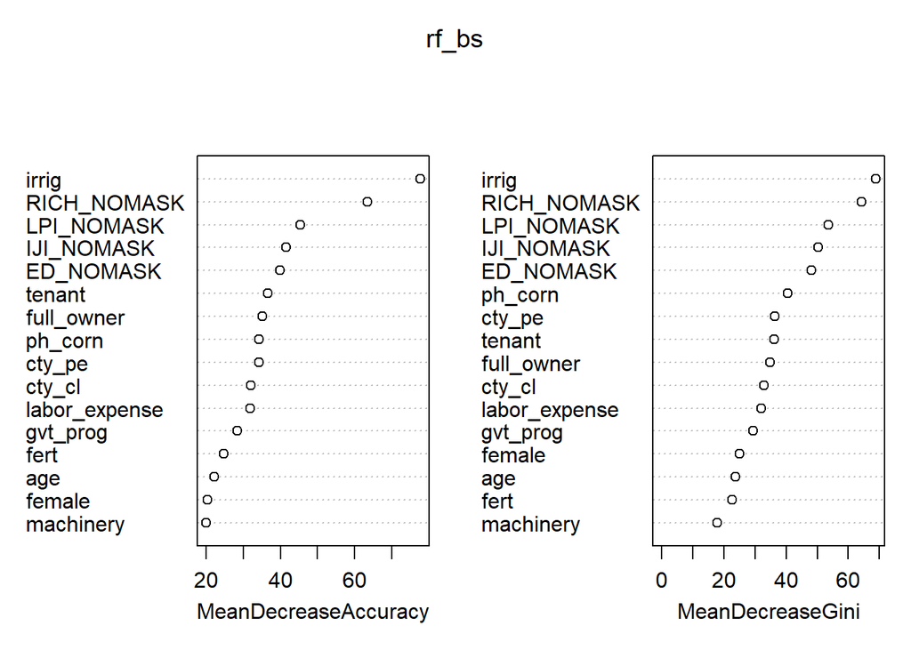

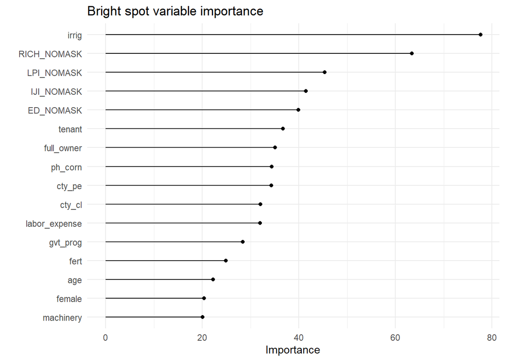

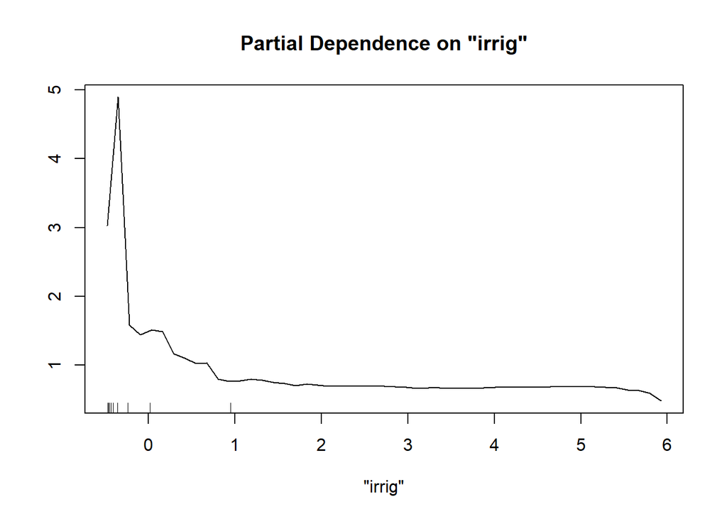

```r
partialPlot(rf_bs, train, "irrig")
```

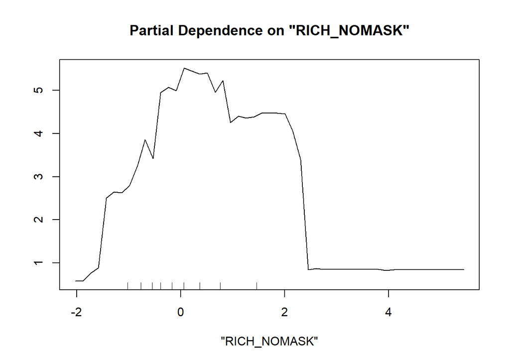

```r
partialPlot(rf_bs, train, "RICH_NOMASK")
```

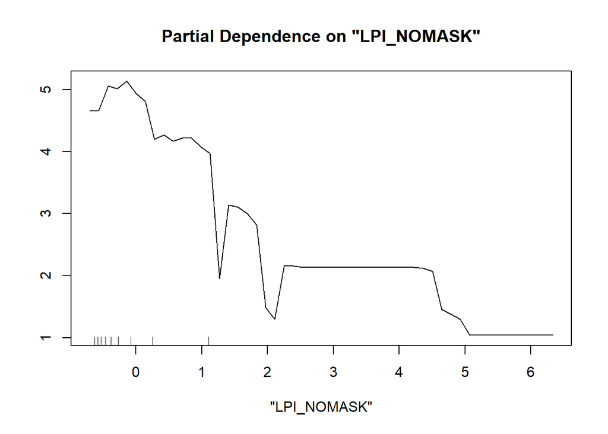

```r
partialPlot(rf_bs, train, "LPI_NOMASK")
```

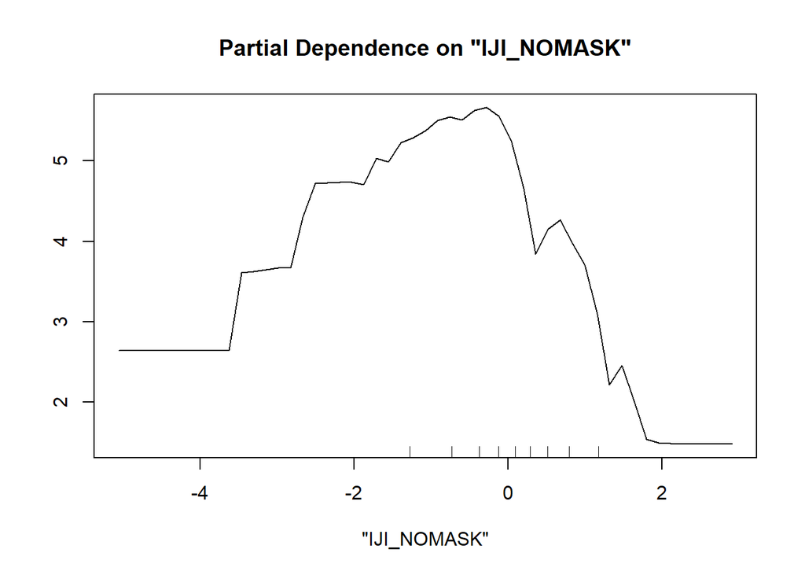

```r
partialPlot(rf_bs, train, "IJI_NOMASK")
```

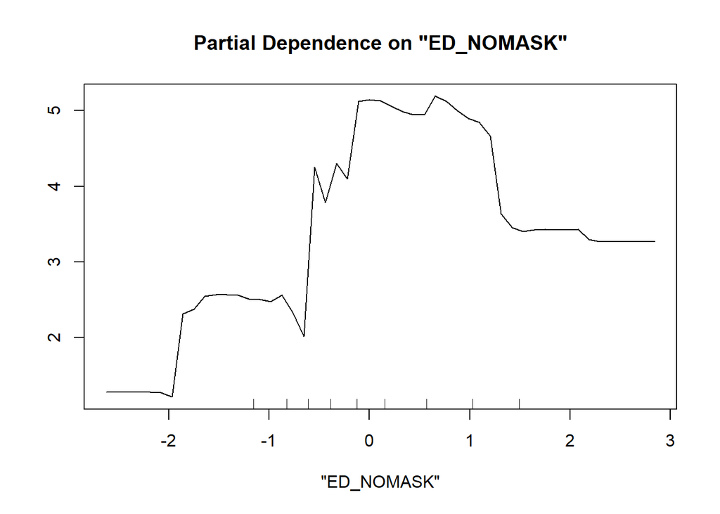

```r
partialPlot(rf_bs, train, "ED_NOMASK")
```

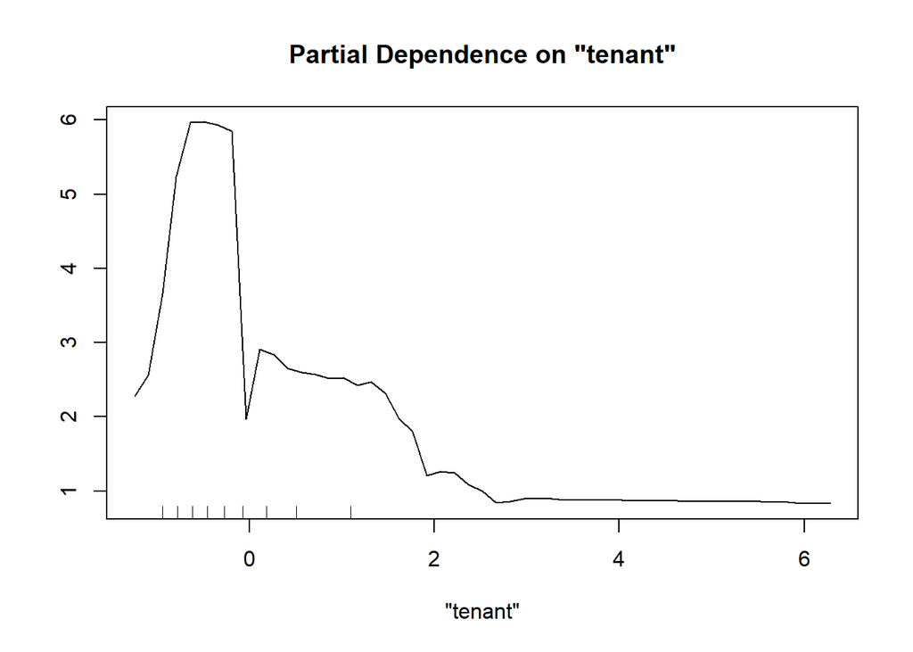

```r
partialPlot(rf_bs, train, "tenant")
```

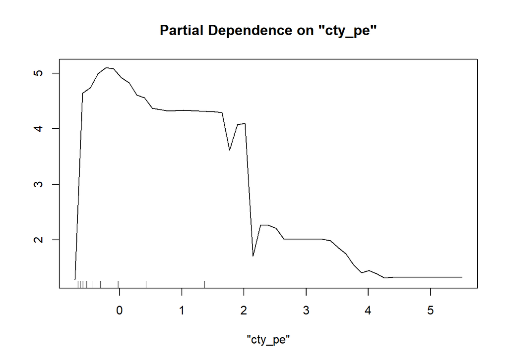

```r
partialPlot(rf_bs, train, "cty_pe")
```

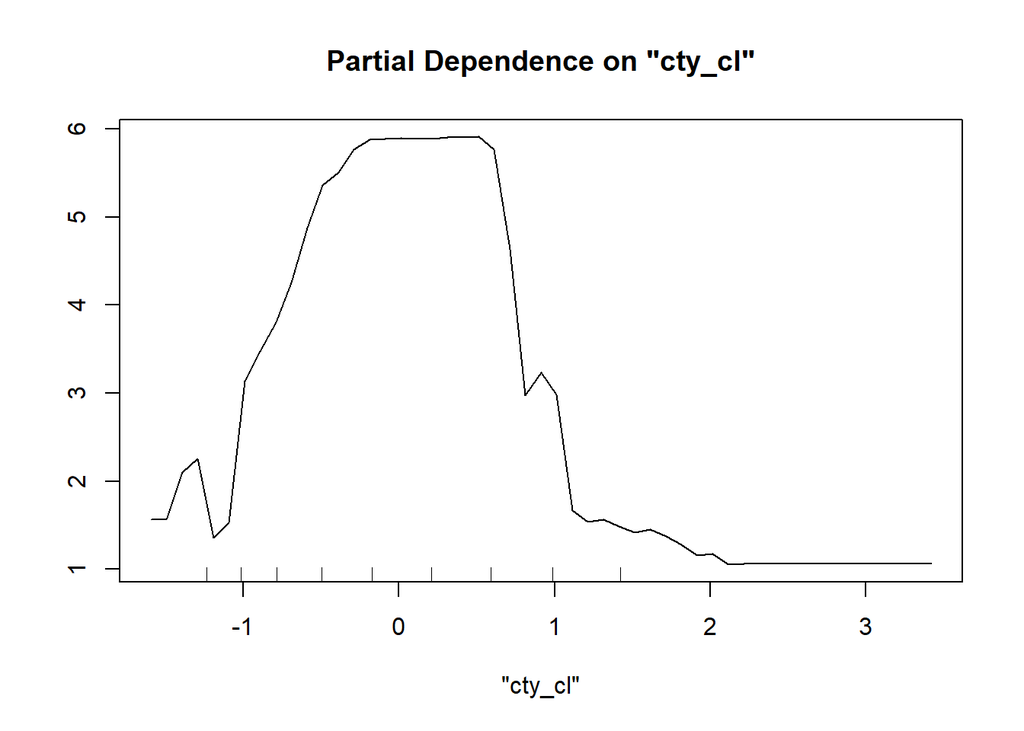

```r
partialPlot(rf_bs, train, "cty_cl")
```

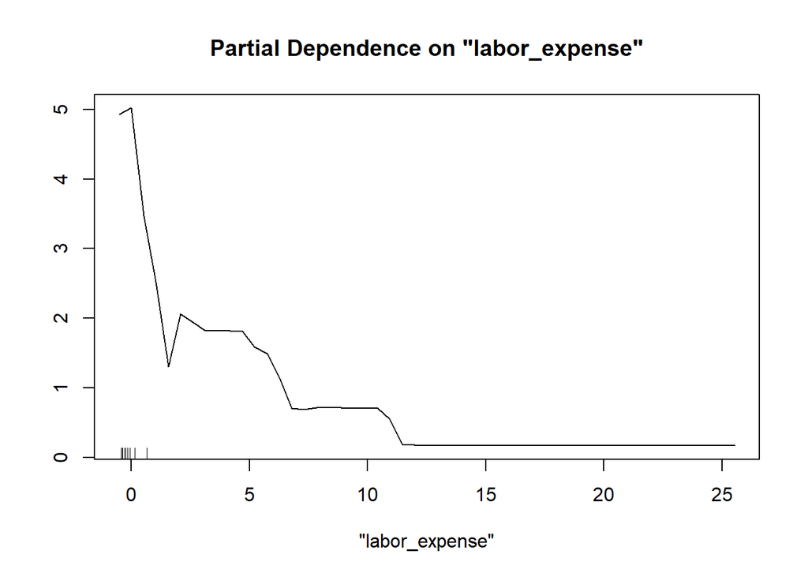

```r
partialPlot(rf_bs, train, "labor_expense")
```

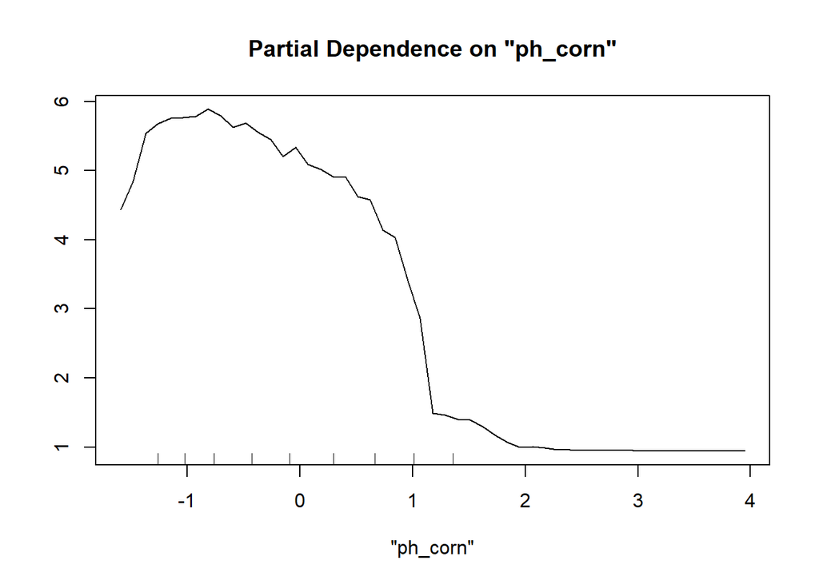

```r
partialPlot(rf_bs, train, "ph_corn")
```

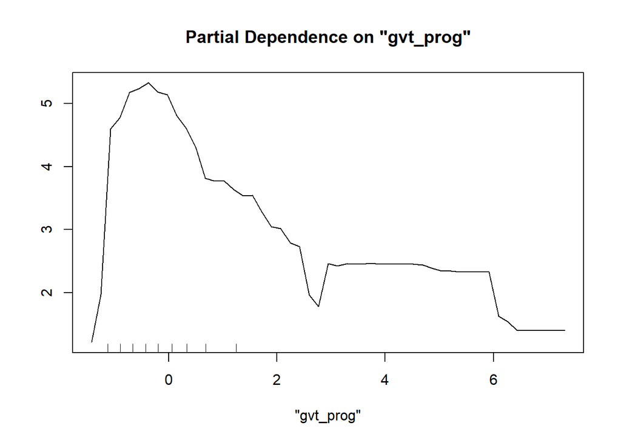

```r
partialPlot(rf_bs, train, "gvt_prog")
```

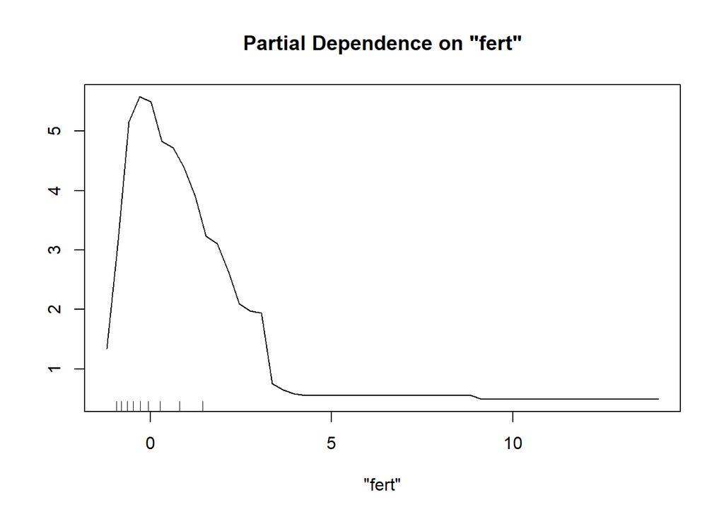

```r
partialPlot(rf_bs, train, "fert")
```

- [Good article to cite](https://digitalcommons.usu.edu/cgi/viewcontent.cgi?article=1805&context=wild_facpub), find other examples to figure out how to present results.

### DS Random Forests (th = 1.5)

```r
rf_ds <- randomForest(formula = DS_BIN ~.,
                   data = train %>% select(-c(BS_BIN)),
                   importance = T,
                   mtry = ncol(train) - 5)
```

Really good performance:

```r
yhat <- predict(rf_ds, newdata = ho)
mean((as.numeric(as.character(yhat)) - as.numeric(as.character(ho$DS_BIN)))^2) # test set MSE
```

```
## [1] 0.03404924
```

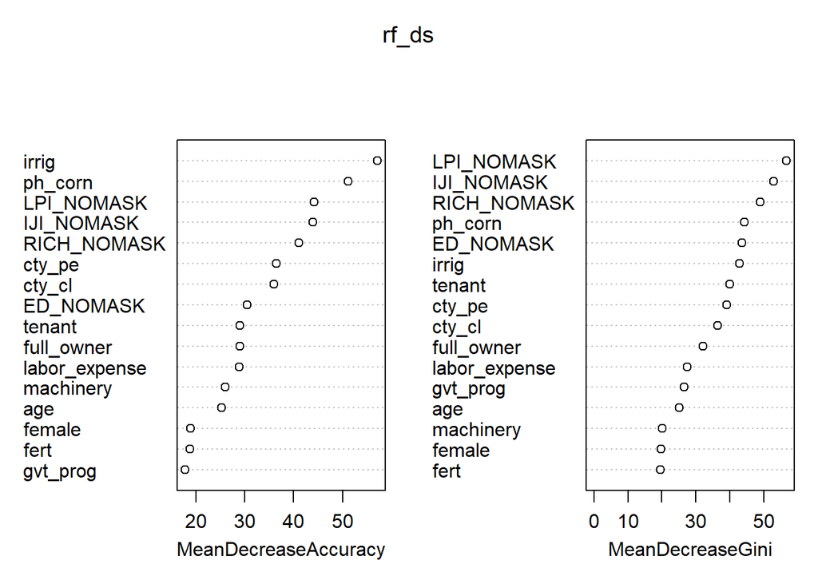

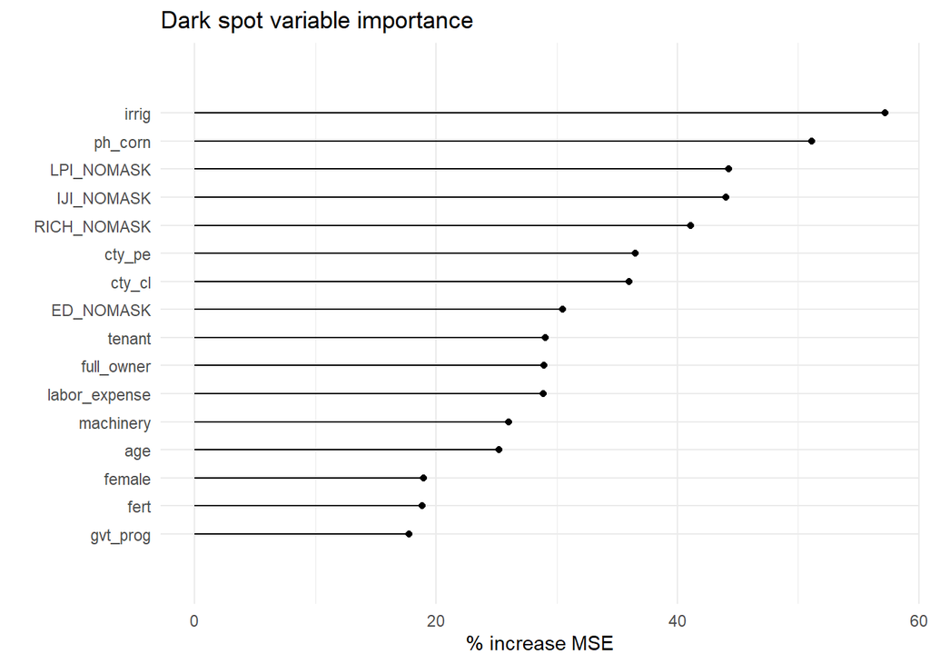

#### DS Partial plots

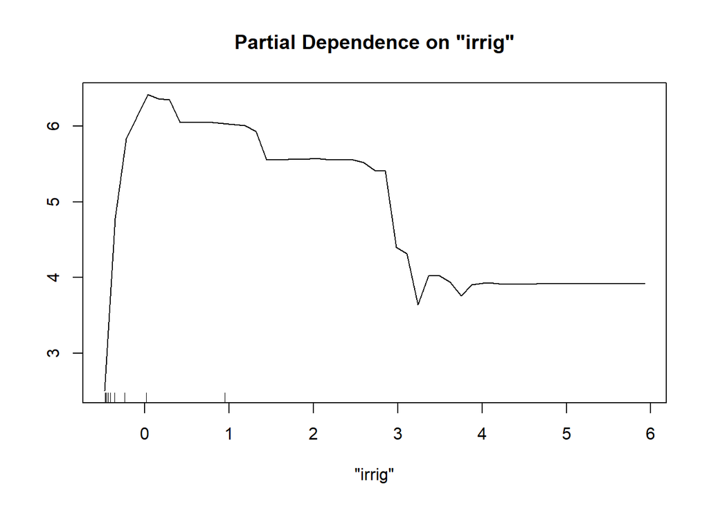

```r
partialPlot(rf_ds, train, "irrig")
```

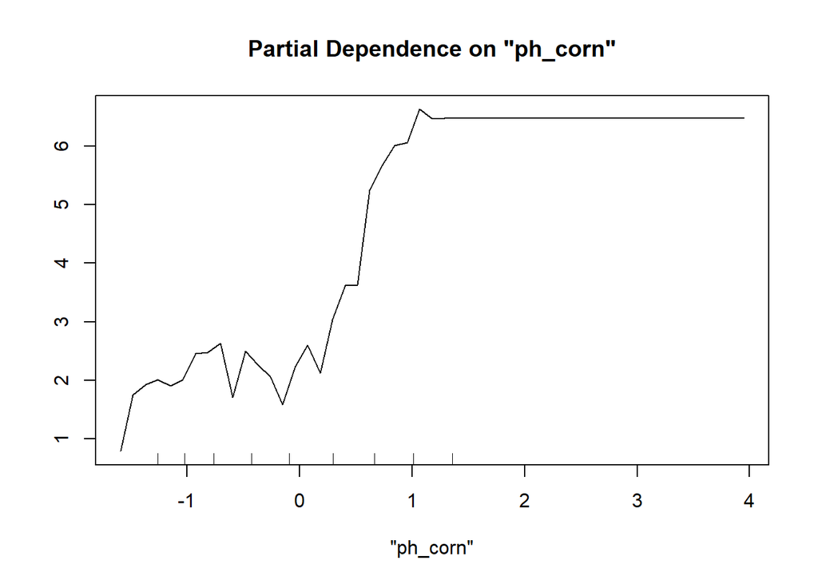

```r
partialPlot(rf_ds, train, "ph_corn")
```

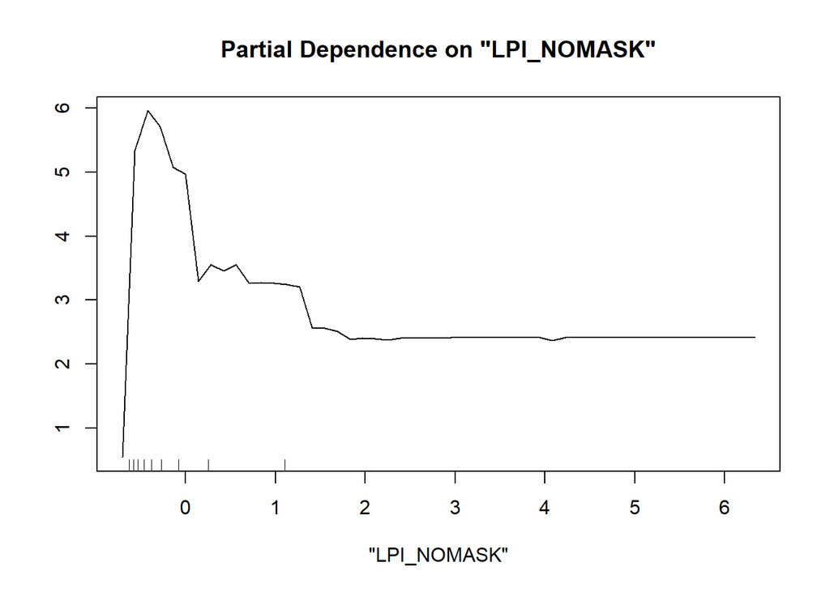

```r
partialPlot(rf_ds, train, "LPI_NOMASK")
```

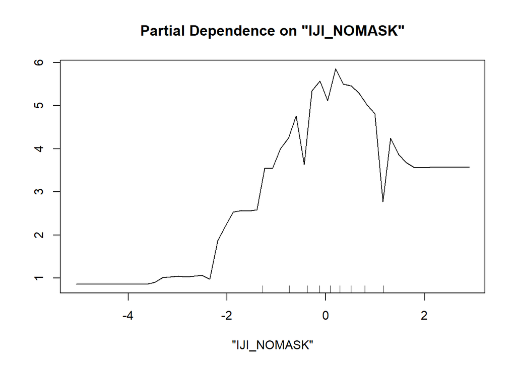

```r
partialPlot(rf_ds, train, "IJI_NOMASK")
```

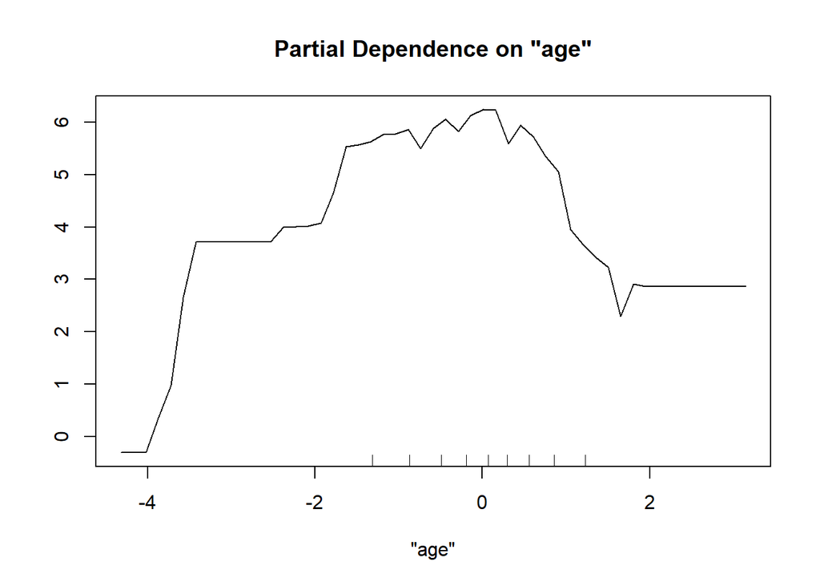

```r
partialPlot(rf_ds, train, "age")
```

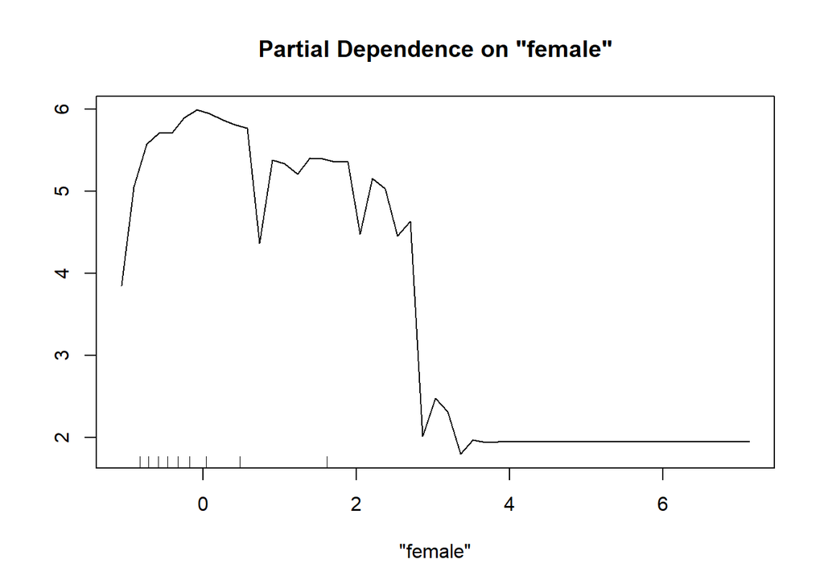

```r
partialPlot(rf_ds, train, "female")
```

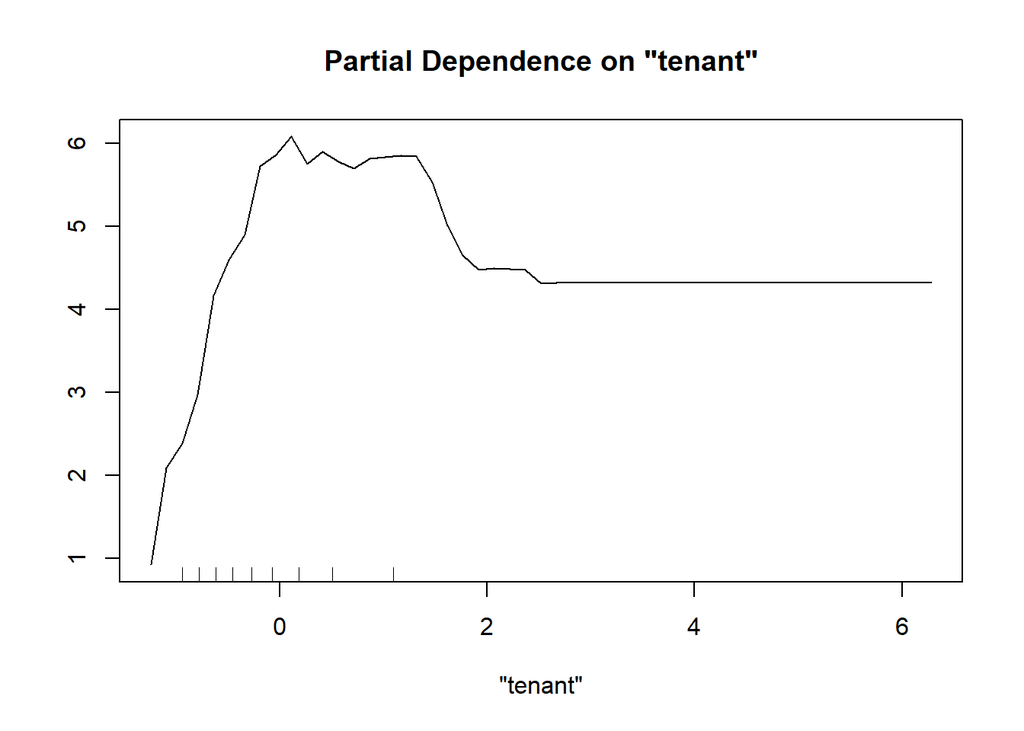

```r
partialPlot(rf_ds, train, "tenant")
```

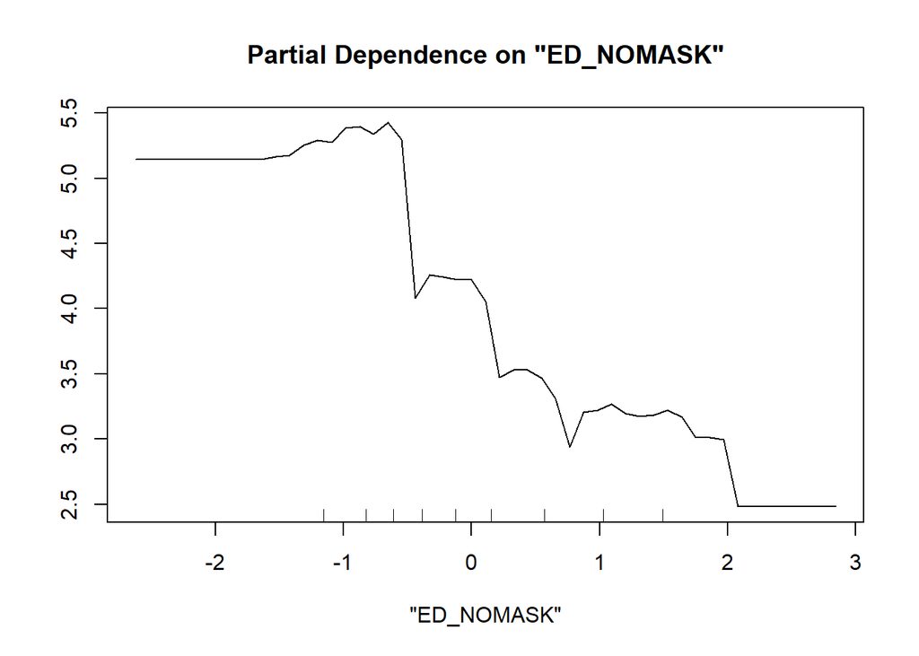

```r
partialPlot(rf_ds, train, "ED_NOMASK")
```

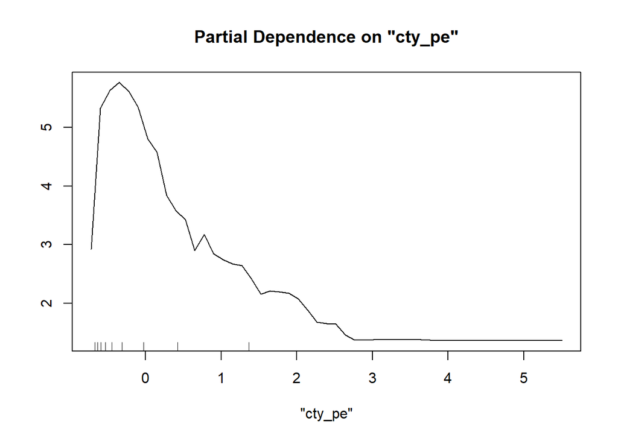

```r
partialPlot(rf_ds, train, "cty_pe")
```

### BS feature selection

```r
library(caret)

# drop NAs as not permitted in predictors
rfeData <- varData %>% na.omit()

# define the control using a random forest selection function
control <- rfeControl(functions=rfFuncs, method="cv", number=10)

# run the RFE algorithm, takes a sec...
results <- rfe(rfeData[,1:(ncol(rfeData) - 2)], rfeData$BS_BIN, sizes = c(seq(from=0, to=30, by=5)), rfeControl = control)

# summarize the results
print(results)

# list the chosen features
predictors(results)

# plot the results
plot(results, type=c("g", "o"))
```

[output not shown]

### DS feature selection

```r
library(caret)

# drop NAs as not permitted in predictors
rfeData <- varData %>% na.omit()

# define the control using a random forest selection function
control <- rfeControl(functions=rfFuncs, method="cv", number=10)

# run the RFE algorithm, takes a sec...
results_ds <- rfe(rfeData[,1:(ncol(rfeData) - 2)], rfeData$DS_BIN, sizes = c(seq(from=0, to=30, by=5)), rfeControl = control)

# summarize the results
print(results_ds)

# list the chosen features
predictors(results_ds)

# plot the results
plot(results_ds, type=c("g", "o"))
```

[output not shown]

### BS logistic regression (th=1.5):

Logistic regression models the *probability* that Y belongs to a particular category (bright spot or dark spot in our case):
$$Pr(BS == 1 | X)$$
where X is our list of covariates. We model $p(X)$ using a logistic function (to avoid estimates outside of the range 0 to 1). Increasing X by one unit increases the log odds by $\beta_1$; but since the relationship between $p(x)$ and X is not a straight line, $\beta_1$ does not correspond to the change in $p(x)$ associated with a one-unit increase in X. This depends on the current value of X. We can interpret the beta coefficients listed below - a one-unit increase in the predictor is associated with a VALUE increase in the log odds of being a bright spot. Note that in multivariate logistic space, this would be *given* the average values of other covariates in the model. Note also that if I intend to use this in final paper, re-run as Bayesian.

```r
# build training and testing datasets
set.seed(1)
random_rn <- sample(nrow(varData), ceiling(nrow(varData)*.25))
ho <- varData[random_rn,]
train <- varData[-random_rn,]

mod <- glm(BS_BIN ~ ., data = train %>% select(-c(DS_BIN)),
           family = "binomial")
summary(mod)
```

```
##
## Call:
## glm(formula = BS_BIN ~ ., family = "binomial", data = train %>%
##     select(-c(DS_BIN)))
##
## Deviance Residuals:
##     Min       1Q   Median       3Q      Max
## -1.8023  -0.3572  -0.2876  -0.2260   2.9969
##
## Coefficients:
##                 Estimate Std. Error z value Pr(>|z|)
## (Intercept)   -4.885e+00  1.755e+00  -2.784 0.005369 **
## age            3.072e-02  2.822e-02   1.088 0.276392
## female         4.974e-05  8.917e-03   0.006 0.995549
## fert           1.149e-02  3.755e-03   3.061 0.002207 **
## full_owner     2.125e-03  6.515e-03   0.326 0.744263
## gvt_prog       2.461e-02  8.466e-03   2.907 0.003650 **
## irrig          2.661e-02  4.249e-03   6.263 3.78e-10 ***
## labor_expense  1.817e-03  8.291e-04   2.192 0.028402 *
## machinery     -2.944e-03  5.978e-04  -4.925 8.45e-07 ***
## tenant         1.863e-02  9.479e-03   1.965 0.049404 *
## cty_cl        -1.625e-02  4.590e-03  -3.541 0.000399 ***
## ph_corn        1.675e-02  3.881e-03   4.316 1.59e-05 ***
## ED_NOMASK     -4.047e-04  2.046e-03  -0.198 0.843182
## IJI_NOMASK     3.808e-02  1.424e-02   2.673 0.007511 **
## LPI_NOMASK    -5.245e-03  6.904e-03  -0.760 0.447429
## RICH_NOMASK   -4.443e-02  1.036e-02  -4.291 1.78e-05 ***
## cty_pe         2.576e-03  5.430e-03   0.474 0.635165
## ---
## Signif. codes:  0 '***' 0.001 '**' 0.01 '*' 0.05 '.' 0.1 ' ' 1
##
## (Dispersion parameter for binomial family taken to be 1)
##
##     Null deviance: 2559.8  on 5699  degrees of freedom
## Residual deviance: 2322.9  on 5683  degrees of freedom
##   (787 observations deleted due to missingness)
## AIC: 2356.9
##
## Number of Fisher Scoring iterations: 6
```

`predict()` predicts the probability of a county being a bright spot given the values of predictors. `type=response` outputs probabilities in the form
$$P(Y=1|X)$$
rather than logit. If no dataset is supplied, `predict()` uses the dataset used to fit the logistic regression above. Prediction on held out data:

```r
glm.probs = predict(mod, ho, type = "response") # testing rate error

# compute predictions on HO and compare to actual observations
glm.pred = rep(0, nrow(ho))
glm.pred[glm.probs > 0.5] = 1
table(glm.pred, ho$BS_BIN)
```

```
##
## glm.pred    0    1
##        0 2040  117
##        1    3    3
```

```r
mean(glm.pred == ho$BS_BIN)
```

```
## [1] 0.9445215
```

```r
mean(glm.pred != ho$BS_BIN) # test set error rate
```

```
## [1] 0.0554785
```

Higher AIC but much less complicated and addresses some of the data collinearlity and redundancy issues.

### DS logistic regression (th=1.5):

```r
# build training and testing datasets
set.seed(1)
random_rn <- sample(nrow(varData), ceiling(nrow(varData)*.25))
ho <- varData[random_rn,]
train <- varData[-random_rn,]

mod <- glm(DS_BIN ~ ., data = train %>% select(-c(BS_BIN)),
           family = "binomial")
summary(mod)
```

```
##
## Call:
## glm(formula = DS_BIN ~ ., family = "binomial", data = train %>%
##     select(-c(BS_BIN)))
##
## Deviance Residuals:
##     Min       1Q   Median       3Q      Max
## -0.8443  -0.3703  -0.2563  -0.1628   3.1815
##
## Coefficients:
##                 Estimate Std. Error z value Pr(>|z|)
## (Intercept)    2.1591831  1.9642730   1.099 0.271669
## age           -0.0253436  0.0317575  -0.798 0.424851
## female        -0.0048192  0.0092023  -0.524 0.600495
## fert          -0.0078882  0.0057327  -1.376 0.168826
## full_owner    -0.0254491  0.0069442  -3.665 0.000248 ***
## gvt_prog       0.0023197  0.0118119   0.196 0.844306
## irrig         -0.0263376  0.0121634  -2.165 0.030363 *
## labor_expense -0.0005324  0.0014060  -0.379 0.704951
## machinery      0.0007951  0.0005603   1.419 0.155885
## tenant        -0.0890303  0.0175266  -5.080 3.78e-07 ***
## cty_cl        -0.0115180  0.0048922  -2.354 0.018554 *
## ph_corn       -0.0504905  0.0055270  -9.135  < 2e-16 ***
## ED_NOMASK     -0.0047226  0.0020024  -2.358 0.018351 *
## IJI_NOMASK     0.0128458  0.0139265   0.922 0.356322
## LPI_NOMASK    -0.0229093  0.0064643  -3.544 0.000394 ***
## RICH_NOMASK   -0.0028568  0.0125484  -0.228 0.819912
## cty_pe         0.0004583  0.0055952   0.082 0.934722
## ---
## Signif. codes:  0 '***' 0.001 '**' 0.01 '*' 0.05 '.' 0.1 ' ' 1
##
## (Dispersion parameter for binomial family taken to be 1)
##
##     Null deviance: 2304.1  on 5699  degrees of freedom
## Residual deviance: 2074.5  on 5683  degrees of freedom
##   (787 observations deleted due to missingness)
## AIC: 2108.5
##
## Number of Fisher Scoring iterations: 7
```

```r
glm.probs = predict(mod, ho, type = "response") # testing rate error

# compute predictions on HO and compare to actual observations
glm.pred = rep(0, nrow(ho))
glm.pred[glm.probs > 0.5] = 1
table(glm.pred, ho$DS_BIN)
```

```
##
## glm.pred    0    1
##        0 2046  117
```

```r
mean(glm.pred == ho$DS_BIN)
```

```
## [1] 0.9459085
```

```r
mean(glm.pred != ho$DS_BIN) # test set error rate
```

```
## [1] 0.05409154
```

### Multinomial logistic

Multinomial versus ordinal decision a bit murky for us, but based on [this](https://www.theanalysisfactor.com/decide-between-multinomial-and-ordinal-logistic-regression-models/), “you can run a nominal model for an ordinal variable and not violate any assumptions. But you may not be answering the research question you’re really interested in if it incorporates the ordering.” “In our data several changes in vegetation could have taken place between each observation. Therefore, for this model, it is assumed that succession of vegetation category does not tend to happen in any particular order and that the categories are strictly nominal.” (From [this](https://besjournals.onlinelibrary.wiley.com/doi/pdf/10.1046/j.1365-2664.2001.00653.x))

Multinomial logistic regression estimates a separate binary logistic regression model for each dummy variable. Each model conveys the effect of predictors on the probability of success *in that category* in comparison to a reference category. This way the predictors can effect each category differently. Here, there’s no assumption of ordinality.  
Nice overview of this approach [here](https://stats.idre.ucla.edu/r/dae/multinomial-logistic-regression/).

Prints out break-down of county-year count of BS/DS/AS:

```r
# standardize data for interpretability
# mlData <- as.data.frame(scale(varData %>% select(-c(BS_BIN, DS_BIN))))
# create categorical predictor
mlData <- varData %>% select(-c(BS_BIN, DS_BIN))
mlData$BS_CAT <- ifelse(varData$BS_BIN == 1, "Bright", NA)
mlData$BS_CAT <- ifelse(varData$DS_BIN == 1, "Dark", mlData$BS_CAT)
mlData$BS_CAT[is.na(mlData$BS_CAT)] <- "Average"
mlData$BS_CAT <- as.factor(mlData$BS_CAT)
# set baseline
mlData$BS_CAT <- relevel(mlData$BS_CAT, ref = "Average")

# build training and testing datasets
set.seed(1)
random_rn <- sample(nrow(mlData), ceiling(nrow(mlData)*.25))
ho <- mlData[random_rn,]
train <- mlData[-random_rn,]

table(mlData$BS_CAT)
```

```
##
## Average  Bright    Dark
##    7662     498     490
```

```r
library(nnet)
ml_out <- multinom(BS_CAT ~ ., data = train)
summary(ml_out)
```

```
## Call:
## multinom(formula = BS_CAT ~ ., data = train)
##
## Coefficients:
##        (Intercept)         age        female         fert  full_owner
## Bright    -4.58182  0.02987418 -0.0002338632  0.011296657  0.00118400
## Dark       2.13884 -0.02421160 -0.0048417449 -0.007547148 -0.02538182
##           gvt_prog      irrig labor_expense     machinery      tenant
## Bright 0.024585635  0.0262318   0.001787344 -0.0029152468  0.01603726
## Dark   0.003800703 -0.0239297  -0.000466521  0.0007002772 -0.08777526
##             cty_cl     ph_corn     ED_NOMASK IJI_NOMASK  LPI_NOMASK
## Bright -0.01691290  0.01499349 -0.0006896588 0.03805872 -0.00658322
## Dark   -0.01231247 -0.04982959 -0.0047346388 0.01462779 -0.02312747
##         RICH_NOMASK       cty_pe
## Bright -0.044804316 0.0028254878
## Dark   -0.005091659 0.0006541015
##
## Std. Errors:
##         (Intercept)        age      female        fert  full_owner
## Bright 0.0001789943 0.01488800 0.008651218 0.003581704 0.006458088
## Dark   0.0001902678 0.01490914 0.008969608 0.005614899 0.006734023
##           gvt_prog       irrig labor_expense    machinery      tenant
## Bright 0.008291979 0.004236343  0.0008275562 0.0005930163 0.009452931
## Dark   0.011721792 0.012233337  0.0014087760 0.0005623520 0.017425666
##             cty_cl     ph_corn   ED_NOMASK IJI_NOMASK  LPI_NOMASK
## Bright 0.004273857 0.003831780 0.002041297 0.01355580 0.006715775
## Dark   0.004663595 0.005399225 0.002002500 0.01353896 0.006392583
##        RICH_NOMASK      cty_pe
## Bright  0.01019815 0.005409060
## Dark    0.01198908 0.005594624
##
## Residual Deviance: 4372.159
## AIC: 4440.159
```

```r
# note that I can add splines like this:
# library(splines)
# ml_out <- multinom(BS_CAT ~ . + bs(SDI_NOMASK, 3), data = train %>% select(-c(BS_BIN, DS_BIN)))
# summary(ml_out)

# quadratic effects here
# https://data.princeton.edu/wws509/r/c6s2
```

So the results starting with `Bright` are comparing the probability of being a `Bright` spot to the reference value of being `Average` and the `Dark` rows are for models comparing the probability of being a `Dark` spot to an `Average` spot. For example, if the value of the `age` coefficient is -0.02, then this means that for a one year increase in a farmer’s age, the logit coefficient (log odds) for `Bright` relative to `Average` will go down by 0.02. So if your age goes up by one unit your chances of staying in the `Average` category are high relative to staying as a bright spot. Another way to describe these effects: The coefficients represent the log-odds of membership in level *j* versus level 1 (baseline) of the response.

These results are presented as log-odds, and are kind of messy to interpret. To compute the *relative risk* (the ratio of the probability of being in one category over the probability of being in the baseline, or “Average” category), we can exponentiate the regression coefficients to compute the relative risk ratios for a one unit change in the predictor variable.

```r
ml_exp <- exp(coef(ml_out))

# results for publication
library(stargazer)
stargazer(ml_out, type = "html", out = "./fig/mnl_results.html")
```

```
##
## <table style="text-align:center"><tr><td colspan="3" style="border-bottom: 1px solid black"></td></tr><tr><td style="text-align:left"></td><td colspan="2"><em>Dependent variable:</em></td></tr>
## <tr><td></td><td colspan="2" style="border-bottom: 1px solid black"></td></tr>
## <tr><td style="text-align:left"></td><td>Bright</td><td>Dark</td></tr>
## <tr><td style="text-align:left"></td><td>(1)</td><td>(2)</td></tr>
## <tr><td colspan="3" style="border-bottom: 1px solid black"></td></tr><tr><td style="text-align:left">age</td><td>0.030<sup>**</sup></td><td>-0.024</td></tr>
## <tr><td style="text-align:left"></td><td>(0.015)</td><td>(0.015)</td></tr>
## <tr><td style="text-align:left"></td><td></td><td></td></tr>
## <tr><td style="text-align:left">female</td><td>-0.0002</td><td>-0.005</td></tr>
## <tr><td style="text-align:left"></td><td>(0.009)</td><td>(0.009)</td></tr>
## <tr><td style="text-align:left"></td><td></td><td></td></tr>
## <tr><td style="text-align:left">fert</td><td>0.011<sup>***</sup></td><td>-0.008</td></tr>
## <tr><td style="text-align:left"></td><td>(0.004)</td><td>(0.006)</td></tr>
## <tr><td style="text-align:left"></td><td></td><td></td></tr>
## <tr><td style="text-align:left">full_owner</td><td>0.001</td><td>-0.025<sup>***</sup></td></tr>
## <tr><td style="text-align:left"></td><td>(0.006)</td><td>(0.007)</td></tr>
## <tr><td style="text-align:left"></td><td></td><td></td></tr>
## <tr><td style="text-align:left">gvt_prog</td><td>0.025<sup>***</sup></td><td>0.004</td></tr>
## <tr><td style="text-align:left"></td><td>(0.008)</td><td>(0.012)</td></tr>
## <tr><td style="text-align:left"></td><td></td><td></td></tr>
## <tr><td style="text-align:left">irrig</td><td>0.026<sup>***</sup></td><td>-0.024<sup>*</sup></td></tr>
## <tr><td style="text-align:left"></td><td>(0.004)</td><td>(0.012)</td></tr>
## <tr><td style="text-align:left"></td><td></td><td></td></tr>
## <tr><td style="text-align:left">labor_expense</td><td>0.002<sup>**</sup></td><td>-0.0005</td></tr>
## <tr><td style="text-align:left"></td><td>(0.001)</td><td>(0.001)</td></tr>
## <tr><td style="text-align:left"></td><td></td><td></td></tr>
## <tr><td style="text-align:left">machinery</td><td>-0.003<sup>***</sup></td><td>0.001</td></tr>
## <tr><td style="text-align:left"></td><td>(0.001)</td><td>(0.001)</td></tr>
## <tr><td style="text-align:left"></td><td></td><td></td></tr>
## <tr><td style="text-align:left">tenant</td><td>0.016<sup>*</sup></td><td>-0.088<sup>***</sup></td></tr>
## <tr><td style="text-align:left"></td><td>(0.009)</td><td>(0.017)</td></tr>
## <tr><td style="text-align:left"></td><td></td><td></td></tr>
## <tr><td style="text-align:left">cty_cl</td><td>-0.017<sup>***</sup></td><td>-0.012<sup>***</sup></td></tr>
## <tr><td style="text-align:left"></td><td>(0.004)</td><td>(0.005)</td></tr>
## <tr><td style="text-align:left"></td><td></td><td></td></tr>
## <tr><td style="text-align:left">ph_corn</td><td>0.015<sup>***</sup></td><td>-0.050<sup>***</sup></td></tr>
## <tr><td style="text-align:left"></td><td>(0.004)</td><td>(0.005)</td></tr>
## <tr><td style="text-align:left"></td><td></td><td></td></tr>
## <tr><td style="text-align:left">ED_NOMASK</td><td>-0.001</td><td>-0.005<sup>**</sup></td></tr>
## <tr><td style="text-align:left"></td><td>(0.002)</td><td>(0.002)</td></tr>
## <tr><td style="text-align:left"></td><td></td><td></td></tr>
## <tr><td style="text-align:left">IJI_NOMASK</td><td>0.038<sup>***</sup></td><td>0.015</td></tr>
## <tr><td style="text-align:left"></td><td>(0.014)</td><td>(0.014)</td></tr>
## <tr><td style="text-align:left"></td><td></td><td></td></tr>
## <tr><td style="text-align:left">LPI_NOMASK</td><td>-0.007</td><td>-0.023<sup>***</sup></td></tr>
## <tr><td style="text-align:left"></td><td>(0.007)</td><td>(0.006)</td></tr>
## <tr><td style="text-align:left"></td><td></td><td></td></tr>
## <tr><td style="text-align:left">RICH_NOMASK</td><td>-0.045<sup>***</sup></td><td>-0.005</td></tr>
## <tr><td style="text-align:left"></td><td>(0.010)</td><td>(0.012)</td></tr>
## <tr><td style="text-align:left"></td><td></td><td></td></tr>
## <tr><td style="text-align:left">cty_pe</td><td>0.003</td><td>0.001</td></tr>
## <tr><td style="text-align:left"></td><td>(0.005)</td><td>(0.006)</td></tr>
## <tr><td style="text-align:left"></td><td></td><td></td></tr>
## <tr><td style="text-align:left">Constant</td><td>-4.582<sup>***</sup></td><td>2.139<sup>***</sup></td></tr>
## <tr><td style="text-align:left"></td><td>(0.0002)</td><td>(0.0002)</td></tr>
## <tr><td style="text-align:left"></td><td></td><td></td></tr>
## <tr><td colspan="3" style="border-bottom: 1px solid black"></td></tr><tr><td style="text-align:left">Akaike Inf. Crit.</td><td>4,440.159</td><td>4,440.159</td></tr>
## <tr><td colspan="3" style="border-bottom: 1px solid black"></td></tr><tr><td style="text-align:left"><em>Note:</em></td><td colspan="2" style="text-align:right"><sup>*</sup>p<0.1; <sup>**</sup>p<0.05; <sup>***</sup>p<0.01</td></tr>
## </table>
```

Adding significance:

```r
eff <- as.data.frame(t(ml_exp))
eff$Variable <- rownames(eff)

# add p-values, Wald test
z <- summary(ml_out)$coefficients/summary(ml_out)$standard.errors
# two tailed Z-test
p <- (1-pnorm(abs(z), 0, 1)) * 2
p <- as.data.frame(t(p))
colnames(p) <- c("Bright_P", "Dark_P")
p$Variable <- rownames(p)

eff <- merge(eff, p, by = "Variable")
eff$Bright_S <- as.factor(ifelse(eff$Bright_P > 0.05, "p > 0.05", "p < 0.05"))
eff$Dark_S <- as.factor(ifelse(eff$Dark_P > 0.05, "p > 0.05", "p < 0.05"))
```

Think through interpretation of [standardized logit](https://stats.stackexchange.com/questions/353654/interpreting-coefficients-in-logistic-regression-after-standardizing-independent) a bit more.

Let’s work on a better way to visualize these relative risk results:

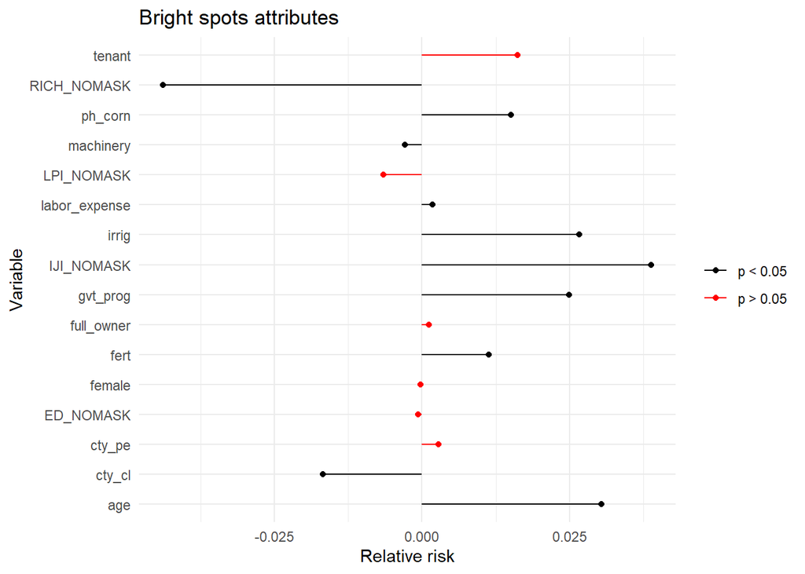

```r
# plot deviations from 1 by variable rather than absolute values for comparison ?
# order lollipops
eff$Bright_Delta <- eff$Bright - 1
eff$Dark_Delta <- eff$Dark - 1

eff <- eff %>%
  filter(Variable != "(Intercept)") %>%
  arrange(desc(Bright_Delta))

ggplot() +
  geom_segment(data = eff, aes(x = 0, y = Variable, xend = Bright_Delta, yend = Variable, color = Bright_S)) +
  geom_point(data = eff, aes(x = Bright_Delta, y = Variable, color = Bright_S)) +
  scale_color_manual(values = c("black", "red")) +
  theme_minimal() +
  theme(legend.title = element_blank()) +
  xlab("Relative risk") +
  ggtitle("Bright spots attributes")
```

```r
th <- 0.25
eff_low <- eff %>% filter(abs(Bright_Delta) < th)
eff_high <- eff %>% filter(abs(Bright_Delta) > th)
eff_high$Bright_Delta_Temp <- ifelse(eff_high$Bright_Delta > 1,th, -th)
ggplot() +
  geom_segment(data = eff_low, aes(x = 0, y = Variable, xend = Bright_Delta, yend = Variable, color = Bright_S)) +
  geom_point(data = eff_low, aes(x = Bright_Delta, y = Variable, color = Bright_S)) +
  scale_color_manual(values = c("black", "red")) +
  theme_minimal() +
  theme(legend.title = element_blank()) +
  xlab("Relative risk") +
  ggtitle("Bright spot") +
  xlim(c(-th-0.1, th+0.1)) +
  geom_segment(data = eff_high, aes(x = 0, y = Variable, xend = Bright_Delta_Temp, yend = Variable, color = Bright_S)) +
  geom_point(data = eff_high, aes(x = Bright_Delta_Temp, y = Variable, color = Bright_S), shape=8) +
  geom_text(data = eff_high, aes(x = Bright_Delta_Temp, y = Variable, label = round(Bright_Delta, 2)),
            hjust = 0, vjust = 1.2, size = 4)
```

[output not shown]

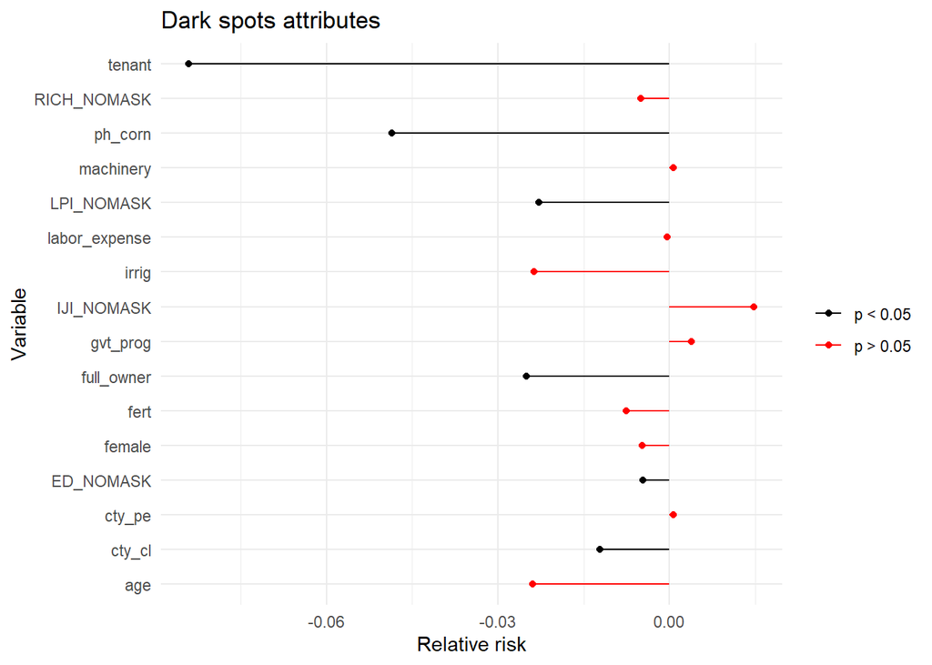

```r
ggplot() +
  geom_segment(data = eff, aes(x = 0, y = Variable, xend = Dark_Delta, yend = Variable, color = Dark_S)) +
  geom_point(data = eff, aes(x = Dark_Delta, y = Variable, color = Dark_S)) +
  scale_color_manual(values = c("black", "red")) +
  theme_minimal() +
  theme(legend.title = element_blank()) +
  xlab("Relative risk") +
  ggtitle("Dark spots attributes")
```

The `effects` documentation calculates [Anovas on results](https://stats.stackexchange.com/questions/63222/getting-p-values-for-multinom-in-r-nnet-package):

```r
library(car)
Anova(ml_out)
```

```
## Analysis of Deviance Table (Type II tests)
##
## Response: BS_CAT
##               LR Chisq Df Pr(>Chisq)
## age              1.769  2  0.4128361
## female           0.281  2  0.8691029
## fert            11.594  2  0.0030367 **
## full_owner      13.555  2  0.0011390 **
## gvt_prog         8.086  2  0.0175466 *
## irrig           40.961  2  1.275e-09 ***
## labor_expense    3.741  2  0.1540481
## machinery       28.774  2  5.646e-07 ***
## tenant          33.366  2  5.683e-08 ***
## cty_cl          19.142  2  6.973e-05 ***
## ph_corn        104.370  2  < 2.2e-16 ***
## ED_NOMASK        5.656  2  0.0591231 .
## IJI_NOMASK       8.151  2  0.0169821 *
## LPI_NOMASK      15.087  2  0.0005296 ***
## RICH_NOMASK     20.518  2  3.503e-05 ***
## cty_pe           0.278  2  0.8700739
## ---
## Signif. codes:  0 '***' 0.001 '**' 0.01 '*' 0.05 '.' 0.1 ' ' 1
```

Performance on held-out data and overall model fit statistics:

```r
prediction_scores <- predict(ml_out, ho, "probs")
prediction_class <- predict(ml_out, ho)

# confusion matrix
table(prediction_class, ho$BS_CAT)
```

```
##
## prediction_class Average Bright Dark
##          Average    1715    111  101
##          Bright        3      3    0
##          Dark          0      0    0
```

```r
# misclassification error
mean(as.character(prediction_class) != as.character(ho$BS_CAT), na.rm=T)
```

```
## [1] 0.1112261
```

```r
# pseudo R2, see this: https://www.rdocumentation.org/packages/DescTools/versions/0.99.19/topics/PseudoR2
library(DescTools)
PseudoR2(ml_out, which = "all")
```

```
##        McFadden     McFaddenAdj        CoxSnell      Nagelkerke
##       0.2317556       0.2198071       0.2065731       0.3270911
##   AldrichNelson VeallZimmermann           Efron McKelveyZavoina
##              NA              NA              NA              NA
##            Tjur             AIC             BIC          logLik
##              NA    4440.1586991    4666.1982285   -2186.0793495
##         logLik0              G2
##   -2845.5517641    1318.9448291
```

More resoures:

- Result interpretation [here](https://www.analyticsvidhya.com/blog/2016/02/multinomial-ordinal-logistic-regression/).
- PNAS paper using approach [here](https://www.pnas.org/content/pnas/106/42/17667.full.pdf)
- Note that may need to test ILA assumption and possibly run a probit model instead - see [this paper](https://www.pnas.org/content/pnas/105/36/13286.full.pdf) that mentions this approach.

```r
library(mlogit)
H <- mlogit.data(train, shape = "wide", choice = "BS_CAT")
ml_out <- mlogit(BS_CAT ~ . | 0, H)
hmftest(ml_out)
```

[output not shown]

The following scripts visualize the probability of being a bright/average/dark spot along a gradient of a particular covariate while holding all other predictors at their mean.

We can be lazy and use the `effects` package which makes some ugly plots:

```r
# effects package, file:///C:/Users/eburchf/Downloads/v32i01%20(1).pdf
library(effects)
# plot(Effect("SDI_NOMASK", ml_out)) # shows predictions with confidence bands
plot(Effect("SDI_NOMASK", ml_out), multiline=T) # multiple lines in one plot.
plot(Effect("SDI_NOMASK", ml_out), style = "stacked") # stacked vertical bar chart of predictions

# effects on splines
# sdi <- effect("bs(SDI_NOMASK, 3)", ml_out,
            #  xlevels = list(SDI_NOMASK = seq(min(mlData[,voi]), max(mlData[,voi]), length.out = nrow(mlData)),
                        #     BS_CAT = c("Dark", "Average", "Bright"))) # add given values for other predictors as mean
# plot(sdi)
# plot(sdi, stype = "stacked", colors = c("blue", "red", "orange"), rug = F)
```

[output not shown]

Or we can do this outself to look at the predicted probabilities for different values of the continuous predictor of interest within each level of the model (Bright, Average, Dark):

[figure not shown]

```r
# reproduces effects plot but more transparent

prob_plot <- function(voi, xlab, n = 500) {
  t <- rep(seq(min(train[,voi], na.rm=T),
             max(train[,voi], na.rm=T), length.out = n), each=3)
  tm <- as.data.frame.list(colMeans(train %>% select(-c(BS_CAT)), na.rm = T))
  tm <- do.call("rbind.data.frame", replicate(length(t), tm, simplify=F))
# tm$BS_CAT <- rep(c("Dark", "Average", "Bright"), n)
  tm[,voi] <- t

  pd <- cbind.data.frame(tm, predict(ml_out, newdata = tm, type = "probs", se = T))

  sub <- gather(pd, "Category", "Probability", c((ncol(pd)-2):ncol(pd)))
  p <- ggplot(data = sub) +
  geom_line(aes(x = sub[,voi], y = Probability, color = Category), size=1.5) +
  xlab(xlab) +
  theme_minimal() +
  theme(legend.title = element_blank()) +
  scale_color_manual(values = c("#a9a9a9", "#4C9A2A", "#000080"), name = "")   +
  ylim(c(0,1))
  return(p)

}

prob_plot(voi = "RICH_NOMASK", xlab = "SDI of agricultural lands")
```

[figure not shown]

```r
prob_plot("LPI_NOMASK", xlab = "SDI of total landscape")
```

[figure not shown]

```r
prob_plot("ED_NOMASK", xlab = "Percent natural cover")
```